# Comparing variable importance orderings across k values

Yi Chen

2024-08-09

# 1 Introduction

[Link to RCE paper](https://link.springer.com/article/10.1007/s10994-013-5337-8)

This document investigates how different $k$ values changes the variable importance orderings produced by RCE. This is quite important as we likely do not know the expected number of clusters *a priori*.

# 2 Parkinsons data set

True $k = 2$

```r
data <- read.table("../example_data/Bases/parkinson.txt", header=F, sep = "\t")
k = ncol(data)
V <- data[, k] # True clustering
true_nclusters <- max(V) # Number of clusters
data <- data[, 1:(k - 1)]

parkinson_ktest = cache_rds({
    lapply(2:10, function(k) {
        mclapply(1:200, function(j) run_RCE(data, nclusters=k, nbiter=200, vfun=ic)$imp, mc.cores=4)
    })
}, rerun=F, clean=T)
names(parkinson_ktest) = paste('k =', 2:10)
```

```r
tmp = sapply(parkinson_ktest, function(x) {
    apply(do.call('cbind', x), 1, mean)
})
tmp = cor(tmp, method = 'spearman')
tmp[lower.tri(tmp, diag=T)] = NA
tmp2 = data.frame(tmp, check.names=F) %>%
    tibble::rownames_to_column('k') %>%
    pivot_longer(!k) %>%
    filter(!is.na(value)) %>%
    mutate(name = factor(name, levels = names(parkinson_ktest))) %>%
    mutate(k = factor(k, levels = names(parkinson_ktest)))
p1 = ggplot(tmp2) +
    geom_tile(aes(x = k, y = name, fill = value)) +
    scale_fill_gradient(name="", low="white", high='steelblue', limits=c(0, 1)) +
    xlab("") +
    ylab("") +
    ggtitle("Spearman Correlation") +
    theme_minimal() +
    theme(axis.text.x = element_text(angle=60, vjust=1, hjust=1))
min_park_spear = min(tmp2$value)
```

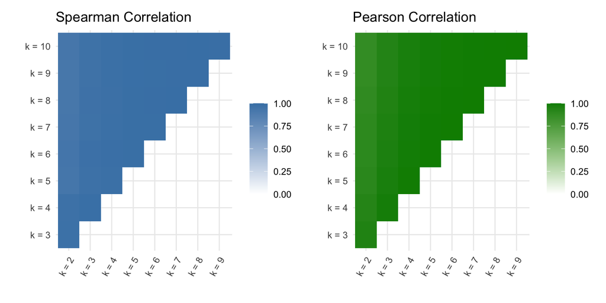

```r
tmp = sapply(parkinson_ktest, function(x) {
    apply(do.call('cbind', x), 1, mean)
})
tmp = cor(tmp, method = 'pearson')
tmp[lower.tri(tmp, diag=T)] = NA
tmp2 = data.frame(tmp, check.names=F) %>%
    tibble::rownames_to_column('k') %>%
    pivot_longer(!k) %>%
    filter(!is.na(value)) %>%
    mutate(name = factor(name, levels = names(parkinson_ktest))) %>%
    mutate(k = factor(k, levels = names(parkinson_ktest)))
p2 = ggplot(tmp2) +
    geom_tile(aes(x = k, y = name, fill = value)) +
    scale_fill_gradient(name="", low="white", high='green4', limits=c(0, 1)) +
    xlab("") +
    ylab("") +
    ggtitle("Pearson Correlation") +
    theme_minimal() +
    theme(axis.text.x = element_text(angle=60, vjust=1, hjust=1))
p1 + p2
```

```r
min_park = min(tmp2$value)
```

# 3 Breast Tissue

True $k = 6$; however, one source claims that 3 classes are not distinguishable using this data set. i.e., $k = 4$

```r
data <- read.table("../example_data/Bases/Breast_Tissu.txt", header=F, sep = "\t")
k = ncol(data)
V <- data[, k] # True clustering
true_nclusters <- max(V) # Number of clusters
data <- data[, 1:(k - 1)]

parkinson_ktest = cache_rds({
    lapply(2:10, function(k) {
        mclapply(1:200, function(j) run_RCE(data, nclusters=k, nbiter=200, vfun=ic)$imp, mc.cores=4)
    })
}, rerun=F, clean=T)
names(parkinson_ktest) = paste('k =', 2:10)
```

```r
tmp = sapply(parkinson_ktest, function(x) {
    apply(do.call('cbind', x), 1, mean)
})
tmp = cor(tmp, method = 'spearman')
tmp[lower.tri(tmp, diag=T)] = NA
tmp2 = data.frame(tmp, check.names=F) %>%
    tibble::rownames_to_column('k') %>%
    pivot_longer(!k) %>%
    filter(!is.na(value)) %>%
    mutate(name = factor(name, levels = names(parkinson_ktest))) %>%
    mutate(k = factor(k, levels = names(parkinson_ktest)))
p1 = ggplot(tmp2) +
    geom_tile(aes(x = k, y = name, fill = value)) +
    scale_fill_gradient(name="", low="white", high='steelblue', limits=c(0, 1)) +
    xlab("") +
    ylab("") +
    ggtitle("Spearman Correlation") +
    theme_minimal() +
    theme(axis.text.x = element_text(angle=60, vjust=1, hjust=1))
min_bt_spear = min(tmp2$value)
```

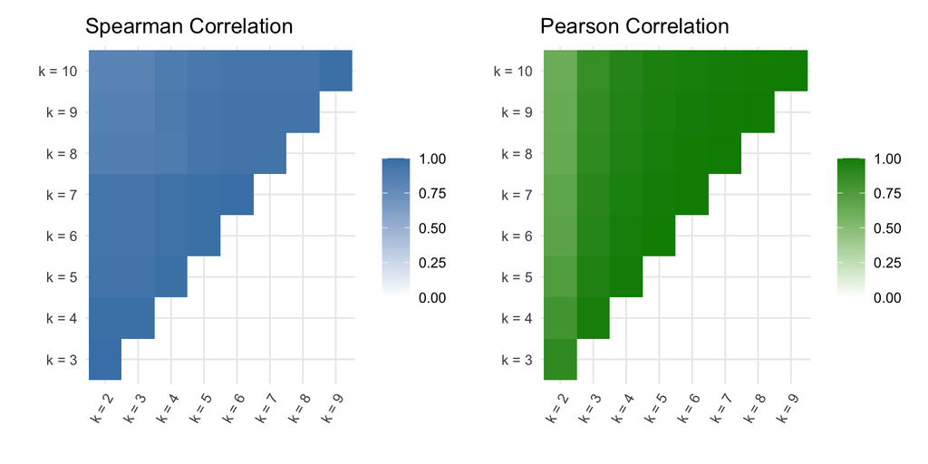

```r
tmp = sapply(parkinson_ktest, function(x) {
    apply(do.call('cbind', x), 1, mean)
})
tmp = cor(tmp, method = 'pearson')
tmp[lower.tri(tmp, diag=T)] = NA
tmp2 = data.frame(tmp, check.names=F) %>%
    tibble::rownames_to_column('k') %>%
    pivot_longer(!k) %>%
    filter(!is.na(value)) %>%
    mutate(name = factor(name, levels = names(parkinson_ktest))) %>%
    mutate(k = factor(k, levels = names(parkinson_ktest)))
p2 = ggplot(tmp2) +
    geom_tile(aes(x = k, y = name, fill = value)) +
    scale_fill_gradient(name="", low="white", high='green4', limits=c(0, 1)) +
    xlab("") +
    ylab("") +
    ggtitle("Pearson Correlation") +
    theme_minimal() +
    theme(axis.text.x = element_text(angle=60, vjust=1, hjust=1))
p1 + p2
```

```r
min_bt = min(tmp2$value)
```

# 4 Conclusions

- Generally, a range of $k$ values around the true number of clusters ($k=2$ for Parkinsons; $k=6$ for Breast Tissue) result in similar variable importance rankings.
- Minimum Spearman correlation is 0.9266 for Parkinsons and 0.8333 for Breast Tissue.
- Minimum Pearson correlation is 0.8721 for Parkinsons and 0.6221 for Breast Tissue.
- The rank order of variable importance appears to be quite stable across different $k$ values, which means that a forward/recursive search would likely be robust to the choice of $k$.
- However, the lower Pearson correlation may indicate that using the scree test as a hard cutoff for variables would potentially yield different sets across $k$ values.